# Лабораторна робота №8

## **Тема. Структура даних граф. Алгоритми на графах**

## **Мета:** засвоїти представлення структури даних граф та основні алгоритми роботи з ними засобами Python.

### *Викoнав Міняйло Марк 19.05.24*

1. Для варіанта, заданого викладачем, задати і візуалізувати граф за допомогою коду, наведеного у цій роботі

{1,2,3,4,5,6,7,8,9}{(1,2),(1,3),(2,4),(3,5),(4,5),(4,6),(6,7),(6,9),(7,8),(7,9),(8,9)}

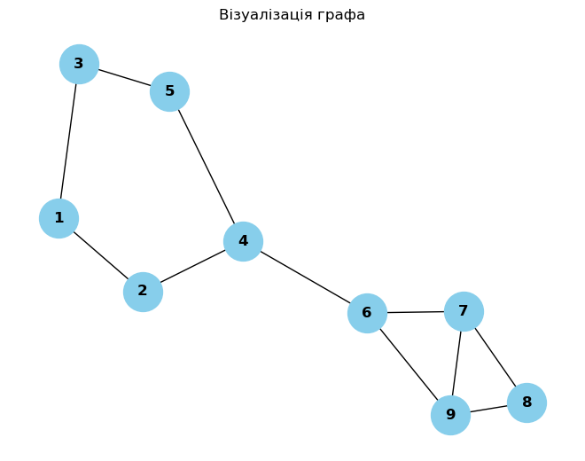

```python
import matplotlib.pyplot as plt
import networkx as nx

# Створюємо граф
G = nx.Graph()

# Додаємо ребра
edges = [(1, 2), (1, 3), (2, 4), (3, 5), (4, 5), (4, 6), (6, 7), (6, 9), (7, 8), (7, 9), (8, 9)]

# Додаємо ребра до графа
G.add_edges_from(edges)

# Візуалізуємо граф
nx.draw(G, with_labels=True, node_size=1000, node_color="skyblue", font_size=12, font_weight="bold")
plt.title("Візуалізація графа")
plt.show()
```

2. Для свого варіанта реалізувати всі алгоритми, згідно з прикладами, наведеними вище

### *Приклад 1.* Створення графа з декількома вершинами та ребрами

```python
import networkx as nx
g = nx.Graph()

# Додавання вершин
for i in range(1, 6):
    g.add_node(i)

# Додавання ребер
g.add_edge(1, 2, weight=5)
g.add_edge(1, 3, weight=3)
g.add_edge(2, 4, weight=2)
g.add_edge(3, 4, weight=7)
g.add_edge(4, 5, weight=1)
g.add_edge(5, 1, weight=4)

# Вивід усіх вершин у графі
print("Вершини у графі:", g.nodes())

# Вивід усіх зв'язків для кожної вершини
for vertex in g:
    print("Для вершини", vertex, "з'єднані вершини:", list(g.neighbors(vertex)))
```

```
Вершини у графі: [1, 2, 3, 4, 5]
Для вершини 1 з'єднані вершини: [2, 3, 5]
Для вершини 2 з'єднані вершини: [1, 4]
Для вершини 3 з'єднані вершини: [1, 4]
Для вершини 4 з'єднані вершини: [2, 3, 5]
Для вершини 5 з'єднані вершини: [4, 1]
```

### Алгоритм Дейкстри

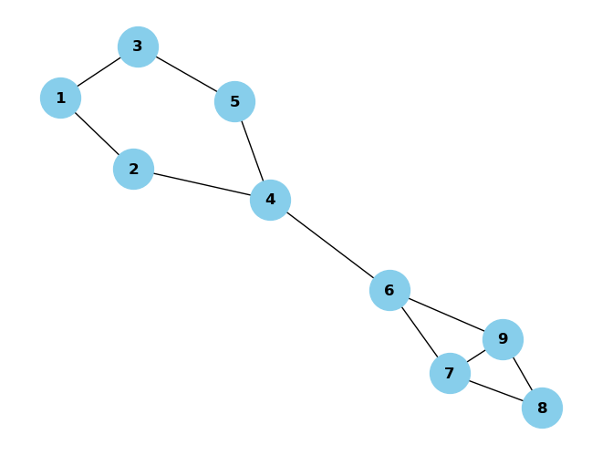

```
4
{1: 0, 2: 1, 3: 1, 4: 2, 5: 2, 6: 3, 7: 4, 9: 4, 8: 5}
```

```python
import networkx as nx
import matplotlib.pyplot as plt

G = nx.Graph()

G.add_nodes_from([1,2,3,4,5,6,7,8,9])
G.add_edges_from([(1,2),(1,3),(2,4),(3,5),(4,5),(4,6),(6,7),(6,9),(7,8),(7,9),(8,9)])

pos = nx.spring_layout(G)
nx.draw(G, pos, with_labels=True, node_size=1000, node_color="skyblue", font_size=12, font_weight="bold")  # Візуалізація графа
plt.show()

length, path = nx.single_source_dijkstra(G, 1)

print(length[9])

print(length)
```

### Алгоритм Белмана-Форда

```python
import networkx as nx

G = nx.Graph()
G.add_nodes_from([1,2,3,4,5,6,7,8,9])
G.add_edges_from([(1,2),(1,3),(2,4),(3,5),(4,5),(4,6),(6,7),(6,9),(7,8),(7,9),(8,9)])

length = nx.single_source_bellman_ford_path_length(G, 1)

print(length[4])

print(length)

length_1 = nx.single_source_bellman_ford_path_length(G, source=1)
print(length_1)
```

```
2
{1: 0, 2: 1, 3: 1, 4: 2, 5: 2, 6: 3, 7: 4, 9: 4, 8: 5}
{1: 0, 2: 1, 3: 1, 4: 2, 5: 2, 6: 3, 7: 4, 9: 4, 8: 5}
```

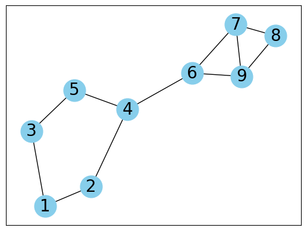

```python
%matplotlib inline

import networkx as nx
import matplotlib.pyplot as plt

G = nx.Graph()

G.add_nodes_from([1, 2, 3, 4, 5, 6, 7, 8, 9])

edges = [(1, 2), (1, 3), (2, 4), (3, 5), (4, 5), (4, 6), (6, 7), (6, 9), (7, 8), (7, 9), (8, 9)]
G.add_edges_from(edges)

pos = nx.spring_layout(G)

nx.draw_networkx_nodes(G, pos, node_size=700, node_color="skyblue")
nx.draw_networkx_labels(G, pos, font_size=20, font_family='sans-serif')

nx.draw_networkx_edges(G, pos, edgelist=G.edges())

plt.show()
```

### Пошук у ширину

```python
def bfs_paths(graph, start, goal):
    queue = [(start, [start])]
    while queue:
        (vertex, path) = queue.pop(0)
        for next in set(graph.adj[vertex].keys()) - set(path):
            if next == goal:
                yield path + [next]
            else:
                queue.append((next, path + [next]))

G = nx.Graph()
G.add_nodes_from([1, 2, 3, 4, 5, 6, 7, 8, 9])
edges = [(1, 2), (1, 3), (2, 4), (3, 5), (4, 5), (4, 6), (6, 7), (6, 9), (7, 8), (7, 9), (8, 9)]
G.add_edges_from(edges)

all_paths = list(bfs_paths(G, 1, 9))
print("Всі шляхи від вершини 1 до вершини 9:", all_paths)
```

```
Всі шляхи від вершини 1 до вершини 9: [[1, 2, 4, 6, 9], [1, 2, 4, 6, 7, 9], [1, 3, 5, 4, 6, 9], [1, 2, 4, 6, 7, 8, 9], [1, 3, 5, 4, 6, 7, 9], [1, 3, 5, 4, 6, 7, 8, 9]]
```

# Контрольні запитання

1. _Що таке граф у термінах теорії графів? Наведіть приклади реальних

ситуацій, де можна застосовувати графи._

Граф – це абстрактний тип даних, який призначений для реалізації концепцій неорієнтованого та орієнтованого графів, що походять з теорії графів. Граф складається з вузлів і вершин. Графи використовуються для представлення структур даних, алгоритмів та складних систем.

2. _Які основні види графів існують? Наведіть відмінності між

орієнтованими і неорієнтованими графами._

Прості графи, циклічні графи, дерева, орієнтовні графи, неорієнтовні графи, псевдографи. Для орієнованих графів важливий напрямок, рухатися можна тільки в сторону стрілки, для неорієнтованого графа сторона руху неважлива.

3. _Як можна представити граф у пам’яті комп'ютера? Опишіть структури

даних, які використовуються для зберігання графів._

Можна представити матрицею суміжності, списком суміжності, класом Graph, Vartex

4. _Як працює алгоритм пошуку в ширину (BFS) на графах? Наведіть

приклади ситуацій, де застосовується цей алгоритм._

Пошук у ширину (breadth-first search, BFS) – це метод обходу графа та пошуку шляхів у ньому. Він відповідає за послідовний перегляд рівнів графа, розпочинаючи з вихідного вузла u. Може використовуватись для пошуку в деревах, відвідавши всі вузли у точному порядку ширини. Може знайти найкоротший шлях, або використовуватись для аналізу графів.

5. _Що таке алгоритм пошуку в глибину (DFS) на графах? Як він

відрізняється від BFS? Дайте приклади задач, де використовується DFS._

Основна мета алгоритму DFS полягає в тому, щоб систематично відвідувати всі вершини та ребра графа. BFS обходить відповідно до рівня дерева, тоді як DFS обходить відповідно до глибини дерева. DFC використовуєтсья для пошуку числа в графі, сортування графу, перевірку на ациклічність, перевірка чи вершина є предком іншої.

6. _Опишіть алгоритм Дейкстри для пошуку найкоротшого шляху в графі.

Які умови повинні виконуватися для успішної роботи цього алгоритму?_

Алгоритм Дейкстри — це алгоритм який знаходить найкоротший шлях від однієї вершини графу до всіх інших вершин. Умови: граф повинен бути зв'язним, ваги повинні бути невід'ємні.